# generative-baseline_task_feedback

```python
import sklearn
import numpy
import random
import itertools
import plotly.express as px
import plotly.io as pio
import plotly.graph_objects as go
from scipy.stats import multivariate_normal
from scipy.spatial.distance import euclidean
pio.renderers.default = "notebook_connected"

#generating the data from the make moons set
data,y = sklearn.datasets.make_moons(n_samples = 100, noise = 0.1)


#implementation of the maximum mean discrepancy with squared exponential kernel
def mmd_squared_se(dataset1, dataset2, h):
    dataset1 = numpy.asarray(dataset1)
    dataset2 = numpy.asarray(dataset2)
    N_1 = len(dataset1)
    N_2 = len(dataset2)

    #vectorized computation of the euclidian distances
    x1_sq = numpy.sum(dataset1**2, axis=1)
    D2_11 = x1_sq[:, None] + x1_sq[None, :] - 2 * dataset1 @ dataset1.T
    K_11 = numpy.exp(-D2_11 / (h**2))
    numpy.fill_diagonal(K_11, 0)
    a = K_11.sum() / (N_1 * (N_1 - 1))


    x2_sq = numpy.sum(dataset2**2, axis=1)
    D2_22 = x2_sq[:, None] + x2_sq[None, :] - 2 * dataset2 @ dataset2.T
    K_22 = numpy.exp(-D2_22 / (h**2))
    numpy.fill_diagonal(K_22, 0)
    b = K_22.sum() / (N_2 * (N_2 - 1))


    D2_12 = x1_sq[:, None] + x2_sq[None, :] - 2 * dataset1 @ dataset2.T
    K_12 = numpy.exp(-D2_12 / (h**2))
    c = 2 * K_12.sum() / (N_1 * N_2)

    return a + b - c


#implemenation of the maxmimum mean discrepancy with inverse multi-qaudratic kernel
def mmd_squared_imq(dataset1, dataset2, h):
    dataset1 = numpy.asarray(dataset1)
    dataset2 = numpy.asarray(dataset2)
    N_1 = len(dataset1)
    N_2 = len(dataset2)


    x1_sq = numpy.sum(dataset1**2, axis=1)
    D2_11 = x1_sq[:, None] + x1_sq[None, :] - 2 * dataset1 @ dataset1.T
    numpy.fill_diagonal(D2_11, numpy.nan)  # i != j
    a = numpy.nansum(1 / numpy.sqrt(1 + D2_11 / h**2)) / (N_1 * (N_1 - 1))


    x2_sq = numpy.sum(dataset2**2, axis=1)
    D2_22 = x2_sq[:, None] + x2_sq[None, :] - 2 * dataset2 @ dataset2.T
    numpy.fill_diagonal(D2_22, numpy.nan)
    b = numpy.nansum(1 / numpy.sqrt(1 + D2_22 / h**2)) / (N_2 * (N_2 - 1))


    D2_12 = x1_sq[:, None] + x2_sq[None, :] - 2 * dataset1 @ dataset2.T
    c = 2 * numpy.sum(1 / numpy.sqrt(1 + D2_12 / h**2)) / (N_1 * N_2)

    return a + b - c
```

2-dimensional histrogram

```python
class two_dimensional_histogram:

    def fit(self,data,bins):
          self.x_max = numpy.max(data[:,0])
          self.x_min = numpy.min(data[:,0])
          self.y_max = numpy.max(data[:,1])
          self.y_min = numpy.min(data[:,1])

          self.bin_height = (self.y_max - self.y_min)/bins
          self.bin_width = (self.x_max-self.x_min)/bins
          self.bin_weights = numpy.zeros((bins,bins))

          #counting the number of data points in each bin and setting the bin weights accordinly
          for i in range(bins):
               for j in range(bins):
                    weight = 0
                    for k in range(len(data)):
                              if self.x_min + i*(self.bin_width) <= data[k][0] <= self.x_min + (i+1)*self.bin_width and self.y_min + j*self.bin_height <= data[k][1] <= self.y_min + (j+1)*self.bin_height:
                                   weight += 1
                    self.bin_weights[i,j] = weight/len(data)

    def sample(self):
          x=random.random() #sampling data point, uniformly distributed
          #variables for choosing a uniformly random point in each bin
          y=random.random()
          z=random.random()

          n = self.bin_weights.shape[0]
          value = 0
          #implemenation of the PPF for the two dimensional histogram: the first bin in which the sum of all previous bin weights exceeds the uniformly distributed variable x gets chosen and a random point in that point is returned
          #as proven in the lecture (in 1D - but this mathematically works the same), this will return data points that are distributed like the 2-D histogram distribution
          for j in range(n):
                for i in range(n):
                      if value < x:
                            value += self.bin_weights[i,j]
                      elif i==0:
                            return [self.x_min + (n-y)*self.bin_width, self.y_min + (j-z)*self.bin_height]
                      else:
                            return[self.x_min + (i-y)*self.bin_width, self.y_min + (j-z)*self.bin_height]
          return self.sample()

    def score_sample(self, data):
          generated_data = []
          try:
                for k in range(100):
                        generated_data.append(self.sample())

                return [mmd_squared_se(data,generated_data,0.1), mmd_squared_imq(data,generated_data,0.1)]
          except NameError:
                  print("The model two dimensional histogram has not been fitted yet.")
```

The fit method is functionally correct. A key area for improvement here is performance. This nested loop approach has a high time complexity. The solution notebook demonstrates a much more efficient, vectorized approach using numpy.digitize which is worth studying.

Single Gaussian

```python
class gaussian:
    def fit(self,data):
        x_mean = 0
        y_mean = 0
        #calculating the mean of the data points
        for i in range(len(data)):
            x_mean += data[i][0]
        x_mean = x_mean/len(data)
        for i in range(len(data)):
            y_mean += data[i][1]
        y_mean = y_mean/len(data)
        self.mean = numpy.array([x_mean, y_mean])

        #calculating the covarianve matrix self.sigma
        self.sigma = numpy.zeros((2,2))
        for i in range(len(data)):
            x_i = numpy.array([data[i][0], data[i][1]])
            self.sigma = self.sigma + numpy.outer((x_i-self.mean),(x_i-self.mean))
        self.sigma = 1/len(data) * self.sigma

        #calculating the diagonalized matrix of Sigma and its square root (exists as Sigma is a positive self adjoint operator on R^2)
        #calculating the orthogonal matrix U, that transforms Sigma into a diagonal matrix
        self.eigvalues, self.eigvectors = numpy.linalg.eigh(self.sigma)
        self.U = self.eigvectors
        self.Lambda_root = numpy.zeros((2,2))
        self.Lambda_root[0,0]=numpy.sqrt(self.eigvalues[0])
        self.Lambda_root[1,1]=numpy.sqrt(self.eigvalues[1])

    #sampling values by the formula given in the lecture, first rotating via U, applying the eigenvalues to each coordinate and then translating by the mean self.mean
    def sample(self):
        x = numpy.random.randn()
        y=  numpy.random.randn()
        z = numpy.array([x,y])
        return z @ self.Lambda_root @ self.U.T + self.mean

    def score_sample(self, data):
          generated_data = []
          try:
                for k in range(100):
                        generated_data.append(self.sample())

                return [mmd_squared_se(data,generated_data,0.1), mmd_squared_imq(data,generated_data,0.1)]
          except NameError:
                  print("The model single gaussian has not been fitted yet.")
```

This implementation is correct. As a note on style and efficiency, the mean and covariance can be calculated directly using numpy.mean(data, axis=0) and numpy.cov(data, rowvar=False). This is more concise and 'NumPy-idiomatic'.

Gaussian Mixture Model

```python
class gmm:
    def fit(self, data, M):
        sigma = []
        mu = []
        pi = []
        epsilon = 1e-6 #i added this because in some cases the intermediate Sigmas in the EM algorithm were not positive definite and this made the program crash when calculating multivariate normal distributions with covariance matrix sigma (it needs to be positive definite for this to work)
        #initializing values for the EM algorithm
        for k in range(M):
            sigma.append(numpy.eye(2))
            i = random.randint(0,len(data)-1)
            mu.append(numpy.array([data[i][0],data[i][1]]))
            pi.append(1/M)

        #EM algorithm (as in the lecture) to fit the weights, means and covariances of the component distributions
        for t in range(50):
            gamma=numpy.zeros((len(data), M))
            for i in range(len(data)):
                for k in range(M):
                    gamma[i,k] = pi[k]*multivariate_normal(mean=mu[k], cov=sigma[k]).pdf(numpy.array([data[i][0],data[i][1]]))/sum(pi[l]*multivariate_normal(mean=mu[l], cov=sigma[l]).pdf(numpy.array([data[i][0],data[i][1]])) for l in range(M))
            for k in range(M):
                sum_gamma = sum(gamma[i,k] for i in range(len(data)))
                pi[k] = 1/len(data) * sum_gamma
                mu[k] = sum(gamma[i,k]*numpy.array([data[i][0],data[i][1]]) for i in range(len(data)))/sum_gamma
                sigma[k] = sum(gamma[i,k]*numpy.outer(numpy.array([data[i][0],data[i][1]])-mu[k],numpy.array([data[i][0],data[i][1]])-mu[k]) for i in range(len(data)))/sum_gamma
                sigma[k] += epsilon* numpy.eye(2)
        self.sigma = sigma
        self.mu=mu
        self.pi=pi
        self.U = []
        self.Lambda_root = []

        #calculating eigen decompositions for all matrices self.sigma[k] as explained above
        for k in range(M):
            eigvals, eigvecs = numpy.linalg.eigh(self.sigma[k])
            self.U.append(eigvecs)
            Lambda_root = numpy.zeros((2,2))
            Lambda_root[0,0] = numpy.sqrt(eigvals[0])
            Lambda_root[1,1] = numpy.sqrt(eigvals[1])
            self.Lambda_root.append(Lambda_root)
    #sampling values by taking normal distributed x,y and transforming them as explained above and in the lecture
    def sample(self):
        x = numpy.random.randn()
        y=  numpy.random.randn()
        z = numpy.array([x,y])
        k = numpy.random.choice(len(self.mu), p=self.pi)
        return z @ self.Lambda_root[k] @ self.U[k].T  + self.mu[k]

    def score_sample(self, data):
          generated_data = []
          try:
                for k in range(100):
                        generated_data.append(self.sample())

                return [mmd_squared_se(data,generated_data,0.1), mmd_squared_imq(data,generated_data,0.1)]
          except NameError:
                  print("The gaussian mixture model has not been fitted yet.")
```

Kernel density estimator

```python
class kde:
    def fit(self, data):
        self.mu = []
        #setting all values for the means of the normal distributions the the KDE
        for k in range(len(data)):
            self.mu.append(numpy.array([data[k][0],data[k][1]]))
    #sampling values by choosing a component and then generating data points that are normally distributed around that component. As the component is chosen uniformly, by the law of large numbers this method will generate data point that are distributed like the density of the KDE
    def sample(self, bandwidth):
        generated_set = []
        k = random.randint(0, len(self.mu)-1)
        return multivariate_normal(self.mu[k], bandwidth*numpy.eye(2)).rvs(1)
        #i allowed myself to use a library for this to make it more readable - i think we proved in the above classes, that we understand and can implement the generation of multivariate gauss distributed data points by hand
    def score_sample(self, data, test_bandwidth):
          generated_data = []
          try:
                for k in range(100):
                        generated_data.append(self.sample(test_bandwidth))

                return [mmd_squared_se(data,generated_data,0.1), mmd_squared_imq(data,generated_data,0.1)]
          except NameError:
                  print("The model two dimensional histogram has not been fitted yet.")
```

Evaluation of the models

Evaluation of the two dimensional histogram

```python
two_dim_hist = two_dimensional_histogram()


#evaluation for varying number of bins
evaluation = []
for k in range(5,50):
    two_dim_hist.fit(data,k)
    evaluation.append(two_dim_hist.score_sample(data))


fig = go.Figure()

for i, (y1, y2) in enumerate(evaluation, start=5):
    fig.add_trace(
        go.Scatter(
            x=[i, i],
            y=[y1, y2],
            mode='lines+markers',
            marker=dict(color='blue', size=6),
            line=dict(color='blue'),
            showlegend=False
        )
    )

fig.update_layout(
    title="Evaluation two dimensional histogram - hyperparameter: number of bins",
    xaxis_title="Number of bins",
    yaxis_title="MMD values",
    template="plotly_white"
)

fig.show()


#evaluation for varying training set size with constant bin size
evaluation = []
for k in range(1,5):
    data,y = sklearn.datasets.make_moons(n_samples = 100*k, noise = 0.1)
    two_dim_hist.fit(data,50)
    evaluation.append(two_dim_hist.score_sample(data))


fig = go.Figure()

for i, (y1, y2) in enumerate(evaluation, start=1):
    fig.add_trace(
        go.Scatter(
            x=[100*i, 100*i],
            y=[y1, y2],
            mode='lines+markers',
            marker=dict(color='blue', size=6),
            line=dict(color='blue'),
            showlegend=False
        )
    )

fig.update_layout(
    title="Evaluation two dimensional histogram - hyperparameter: training set size",
    xaxis_title="Training set size",
    yaxis_title="MMD values",
    template="plotly_white"
)

fig.show()
```

[interactive chart not shown]

Comment: With increased number of bins, the accuracy (with both kernels) drastically improve. This is due to the finer resolution in of the data points in bins. The training set size does not appear to make a great difference if it exceeds 100. The numerical inaccuracies that produce negative values seem to have a stronger effect than the training set size.

Regarding the evaluation plots (e.g., "Evaluation two dimensional histogram - hyperparameter: number of bins" ): While your custom line-and-marker plots do show the range of the two MMD scores (SE and IMQ) , I find them a bit hard to interpret intuitively at a glance. May be you could consider plots in given example.

Evaluation single gaussian

```python
print("As the single gaussian has no hyper parameters, we will just show 1) a plot the real data set and 2) a plot of the set generated by the single gaussian")

A = numpy.array(data)
fig = px.scatter(x=A[:, 0], y=A[:, 1],
                 title="Training set make moons",
                 labels={'x': 'x', 'y': 'y'})
fig.update_traces(marker=dict(size=8, color='royalblue'))
fig.show()




test_gaussian = gaussian()
test_gaussian.fit(data)
generated_data = []
for i in range(200):
      generated_data.append(test_gaussian.sample())
A = numpy.array(generated_data)
fig = px.scatter(x=A[:, 0], y=A[:, 1],
                 title="Data generated by gaussian",
                 labels={'x': 'x', 'y': 'y'})
fig.update_traces(marker=dict(size=8, color='royalblue'))
fig.show()
```

```
As the single gaussian has no hyper parameters, we will just show 1) a plot the real data set and 2) a plot of the set generated by the single gaussian
```

[interactive chart not shown]

Comment: As we can see, the gaussian does not match the training data well. This is no suprise as the gaussian can only have one "accumulation point" where as the training set has two distinct connected components. Therefore the gaussian by design can not match the training set well.

Evaluation gaussian mixture model

```python
gaussian_mixture = gmm()

print("This may take about a minute, as the EM algorithm is done for every number of components from 1 to 6 and then again for different training sets.")
print("In the mean time, this is a plot of the gmm in 6 components")

data,y = sklearn.datasets.make_moons(n_samples = 100, noise = 0.1)

gaussian_mixture.fit(data, 6)
generated_data = []
for i in range(400):
      generated_data.append(gaussian_mixture.sample())
A = numpy.array(generated_data)
fig = px.scatter(x=A[:, 0], y=A[:, 1],
                 title="Data generated by gaussian mixture model",
                 labels={'x': 'x', 'y': 'y'})
fig.update_traces(marker=dict(size=8, color='royalblue'))
fig.show()



#evaluation for varying component number from 1 to 6
evaluation = []
for k in range(1,7):
    gaussian_mixture.fit(data,k)
    evaluation.append(gaussian_mixture.score_sample(data))


fig = go.Figure()

for i, (y1, y2) in enumerate(evaluation, start=1):
    fig.add_trace(
        go.Scatter(
            x=[i, i],
            y=[y1, y2],
            mode='lines+markers',
            marker=dict(color='blue', size=6),
            line=dict(color='blue'),
            showlegend=False
        )
    )

fig.update_layout(
    title="Evaluation Gaussian mixture model - hyperparameter: number of components",
    xaxis_title="Number of components of the gmm",
    yaxis_title="MMD values",
    template="plotly_white"
)

fig.show()




#evaluation for varying training set size with constant number of components (4)
evaluation = []
for k in range(1,5):
    data,y = sklearn.datasets.make_moons(n_samples = 40*k, noise = 0.1)
    gaussian_mixture.fit(data,4)
    evaluation.append(gaussian_mixture.score_sample(data))


fig = go.Figure()

for i, (y1, y2) in enumerate(evaluation, start=1):
    fig.add_trace(
        go.Scatter(
            x=[40*i, 40*i],
            y=[y1, y2],
            mode='lines+markers',
            marker=dict(color='blue', size=6),
            line=dict(color='blue'),
            showlegend=False
        )
    )

fig.update_layout(
    title="Evaluation gaussian mixture model (4 components) - hyperparameter: training set size",
    xaxis_title="Training set size",
    yaxis_title="MMD values",
    template="plotly_white"
)

fig.show()
```

```
This may take about a minute, as the EM algorithm is done for every number of components from 1 to 6 and then again for different training sets.
In the mean time, this is a plot of the gmm in 6 components
```

[interactive chart not shown]

Comment: As suspected, the MMD values get smaller with increasing number of components, because the more components we have, the less "smearing" is done in each component (the covariance can be lower and we still "cover" most of the data points in the training set). The training set size again does not appear outweigh the numerical inaccuracies in the computation of the MMD^2 metrics.

Evalution Kernel density estimation

```python
kernel_density = kde()
#evaluation for varying bandwidth
evaluation = []
for k in range(1,50):
    kernel_density.fit(data)
    evaluation.append(kernel_density.score_sample(data, test_bandwidth=1/k))


fig = go.Figure()

for i, (y1, y2) in enumerate(evaluation, start=5):
    fig.add_trace(
        go.Scatter(
            x=[i, i],
            y=[y1, y2],
            mode='lines+markers',
            marker=dict(color='blue', size=6),
            line=dict(color='blue'),
            showlegend=False
        )
    )

fig.update_layout(
    title="Evaluation Kernel density estimation - hyperparameter: bandwidth",
    xaxis_title="Bandwidth 1/n",
    yaxis_title="MMD values",
    template="plotly_white"
)

fig.show()



#evaluation for varying training set size with constant bandwidth (1/20)
evaluation = []
for k in range(1,5):
    data,y = sklearn.datasets.make_moons(n_samples = 40*k, noise = 0.1)
    kernel_density.fit(data)
    evaluation.append(kernel_density.score_sample(data, test_bandwidth=1/20))


fig = go.Figure()

for i, (y1, y2) in enumerate(evaluation, start=1):
    fig.add_trace(
        go.Scatter(
            x=[40*i, 40*i],
            y=[y1, y2],
            mode='lines+markers',
            marker=dict(color='blue', size=6),
            line=dict(color='blue'),
            showlegend=False
        )
    )

fig.update_layout(
    title="Evaluation kernel density estimation (bandwidth 1/20) - hyperparameter: training set size",
    xaxis_title="Training set size",
    yaxis_title="MMD values",
    template="plotly_white"
)

fig.show()
```

[interactive chart not shown]

Comment: As the bandwidth gets lower, we deviate less from the original data points and thus practically choose random points from the data set and only variate them with a little noise. The accuracy is of course higher, but there is little to no new information gained from that process. Unfortunately the training set size again does not outweigh the numerical inaccuracies.

Visualization of the densities:

```python
data,y = sklearn.datasets.make_moons(n_samples = 200, noise = 0.1)

gaussian_mixture = gmm()
gaussian_mixture.fit(data, 4)
generated_data = []
for i in range(10000):
      generated_data.append(gaussian_mixture.sample())
A = numpy.array(generated_data)
fig = px.scatter(x=A[:, 0], y=A[:, 1],
                 title="Visualization of the density for a GMM in 4 components",
                 labels={'x': 'x', 'y': 'y'})
fig.update_traces(marker=dict(size=2, color='royalblue'))
fig.show()
```

[interactive chart not shown]

```python
import numpy as np
from sklearn.datasets import load_digits
from sklearn.mixture import GaussianMixture
from sklearn.neighbors import KernelDensity

# Load the digits dataset
digits = load_digits()
data = digits.data
labels = digits.target
```

[output not shown]

```python
import numpy as np
from sklearn.metrics import pairwise_distances

def _se_kernel(sq_distances, h):
    """Computes the squared exponential (RBF) kernel matrix."""
    return np.exp(-sq_distances / (h**2))

def _imq_kernel(sq_distances, h):
    """Computes the inverse multi-quadratic kernel matrix."""
    return 1. / np.sqrt(1 + sq_distances / (h**2))

def mmd2(X, Y, h, kernel_type='se'):
    """
    Computes the Maximum Mean Discrepancy (MMD²) between two samples, X and Y.

    Args:
        X (np.ndarray): The first sample (e.g., real data), shape (m, n_features).
        Y (np.ndarray): The second sample (e.g., generated data), shape (n, n_features).
        h (float): The kernel bandwidth.
        kernel_type (str): 'se' for squared exponential or 'imq' for inverse multi-quadratic.

    Returns:
        float: The MMD² statistic.
    """

    # choose the kernel function
    if kernel_type == 'se':
        kernel_func = lambda sq_dist: _se_kernel(sq_dist, h)
    else:
        kernel_func = lambda sq_dist: _imq_kernel(sq_dist, h)


    # calculate squared Euclidean distances for all pairs
    K_XX_dist = pairwise_distances(X, X, metric='sqeuclidean')
    K_YY_dist = pairwise_distances(Y, Y, metric='sqeuclidean')
    K_XY_dist = pairwise_distances(X, Y, metric='sqeuclidean')

    # apply the kernel to the distance matrices
    K_XX = kernel_func(K_XX_dist)
    K_YY = kernel_func(K_YY_dist)
    K_XY = kernel_func(K_XY_dist)

    # compute the MMD² statistic
    m = len(X)
    n = len(Y)

    mmd2_val = (np.sum(K_XX) / (m**2) +
                np.sum(K_YY) / (n**2) -
                2 * np.sum(K_XY) / (m * n))

    return mmd2_val
```

Your mmd2 function implemented here is a biased estimator. This is different from the unbiased estimator you implemented in Task 1 . While both are practically valid , it's good to be aware of and maintain consistency. This is just a minor observation, not an error.

```python
from density_forest import DensityForest

# Density Forest
df_model = DensityForest(n_trees=20, n_min=10)
df_model.fit(data)

# generate new samples
n_samples = 100
df_samples = df_model.sample(n_samples)
```

```python
# Gaussian Mixture Model
gmm_model = GaussianMixture(n_components=20, random_state=42) # 20 components worked well
gmm_model.fit(data)

# generate 100 samples
gmm_samples = gmm_model.sample(n_samples=100)[0]
```

```python
# Kernel Density Estimation
kde_model = KernelDensity(kernel='gaussian', bandwidth=0.5) # bandwith 0.5 worked well
kde_model.fit(data)

print("Model fitting complete.")

# Generate 100 new "fake" digits
kde_samples = kde_model.sample(n_samples=100)

print(f"Generated {n_samples} samples. Shape: {kde_samples.shape}")
```

```
Model fitting complete.
Generated 100 samples. Shape: (100, 64)
```

```python
# evaluate models

from sklearn.metrics import pairwise_distances

# Calculate pairwise distances (not on all)
sample_indices = np.random.choice(data.shape[0], 1000, replace=False)
distances = pairwise_distances(data[sample_indices], metric='euclidean')
# median of the distances
h_median = np.median(distances[distances > 0])
print(f"Median-bandwith (h) for MMD: {h_median:.4f}")


# calculate MMD² for each model:
# MMD for Density Forest
mmd_df = mmd2(data, df_samples, h=h_median, kernel_type='se')
print(f"Density Forest: {mmd_df:.6f}")

# for GMM
mmd_gmm = mmd2(data, gmm_samples, h=h_median, kernel_type='se')
print(f"GMM: {mmd_gmm:.6f}")

# for KDE
mmd_kde = mmd2(data, kde_samples, h=h_median, kernel_type='se')
print(f"KDE: {mmd_kde:.6f}")
```

```
Median-bandwith (h) for MMD: 49.0714
Density Forest: 0.005994
GMM: 0.005554
KDE: 0.003665
```

```python
# train model on real digits

from sklearn.model_selection import train_test_split
from sklearn.ensemble import RandomForestClassifier
from sklearn.metrics import accuracy_score

# split data
X_train, X_test, y_train, y_test = train_test_split(data, labels, test_size=0.2, random_state=42, stratify=labels)

# train the classifier on the real data
classifier = RandomForestClassifier(n_estimators=100, random_state=42)
classifier.fit(X_train, y_train)

# check accuracy
y_pred = classifier.predict(X_test)
accuracy = accuracy_score(y_test, y_pred)

print(f"accuracy: {accuracy * 100:.2f}%")
```

```
accuracy: 96.11%
```

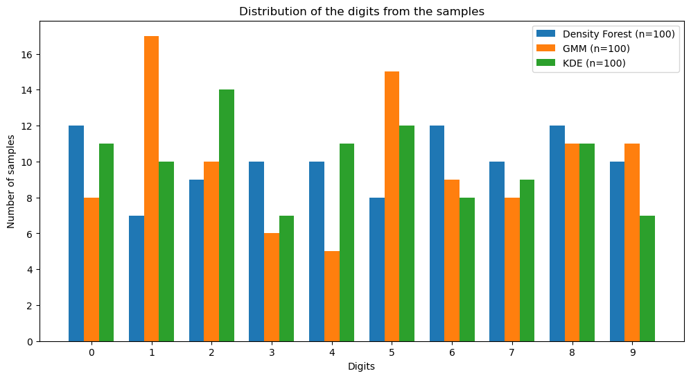

```python
# test distribution of digits

import numpy as np
import matplotlib.pyplot as plt

# make predictions for the generated data
pred_df = classifier.predict(df_samples)
pred_gmm = classifier.predict(gmm_samples)
pred_kde = classifier.predict(kde_samples)

# calculate the distribution of recognized digits (0-9)
counts_df = np.bincount(pred_df, minlength=10)
counts_gmm = np.bincount(pred_gmm, minlength=10)
counts_kde = np.bincount(pred_kde, minlength=10)

# visualize
digits_x = np.arange(10)
width = 0.25

fig, ax = plt.subplots(figsize=(12, 6))
ax.bar(digits_x - width, counts_df, width, label=f'Density Forest (n={len(df_samples)})')
ax.bar(digits_x, counts_gmm, width, label=f'GMM (n={len(gmm_samples)})')
ax.bar(digits_x + width, counts_kde, width, label=f'KDE (n={len(kde_samples)})')

ax.set_title('Distribution of the digits from the samples')
ax.set_ylabel('Number of samples')
ax.set_xlabel('Digits')
ax.set_xticks(digits_x)
ax.set_xticklabels(digits_x)
ax.legend()

plt.show()
```

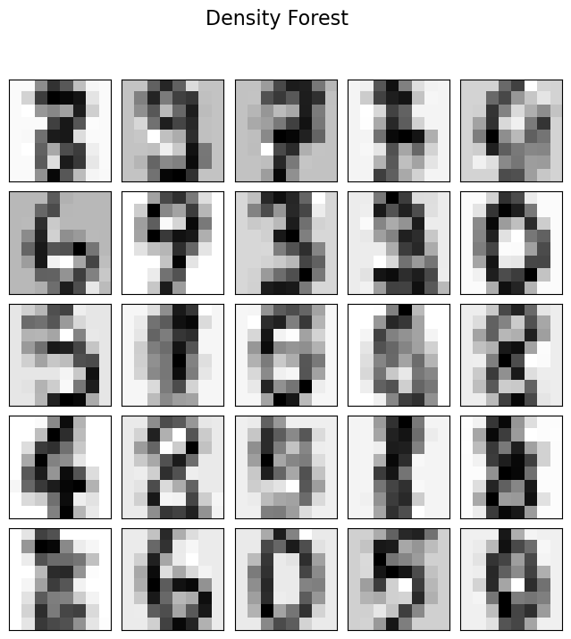

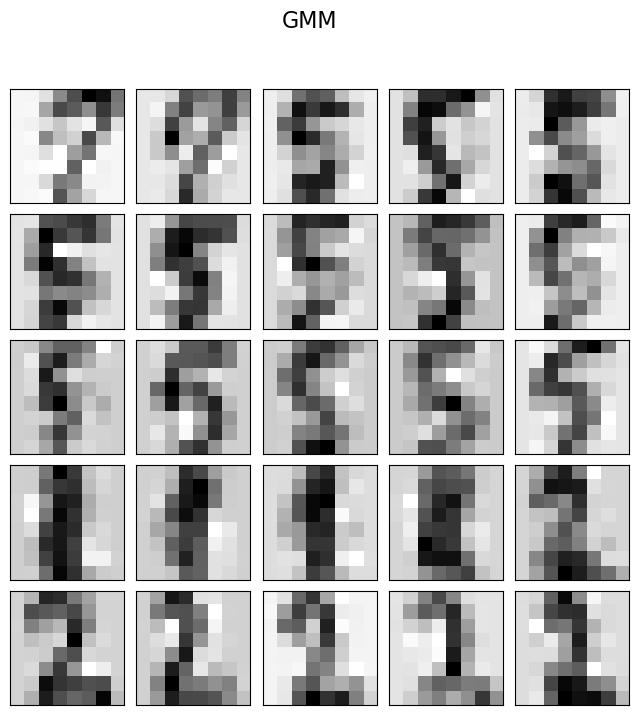

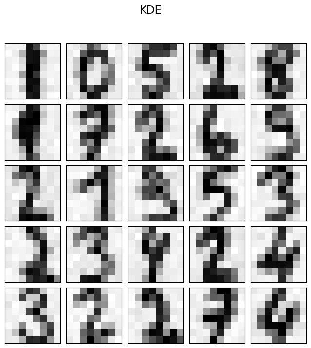

```python
# print samples

def plot_generated_digits(samples, model_name):
    fig, axes = plt.subplots(5, 5, figsize=(8, 8),
                             subplot_kw={'xticks':[], 'yticks':[]},
                             gridspec_kw=dict(hspace=0.1, wspace=0.1))

    for i, ax in enumerate(axes.flat):
        if i < len(samples):
            # Reshape 64D vector
            image = samples[i].reshape(8, 8)
            ax.imshow(image, cmap='gray_r')

    plt.suptitle(f"{model_name}", fontsize=16)
    plt.show()

# Density Forest
plot_generated_digits(df_samples, "Density Forest")

# GMM
plot_generated_digits(gmm_samples, "GMM")

# KDE
plot_generated_digits(kde_samples, "KDE")
```

Based on the MMD score, the KDE model was statistically the most accurate.

The Density Forest model was the most balanced, producing the best variety of all 10 digits, even though its MMD score was the highest.

This shows that a model can be statistically accurate (low MMD) but still be a poor generative model if it fails to create diversity.

```python
data,y = sklearn.datasets.make_moons(n_samples = 200, noise = 0.1)

two_dim_hist = two_dimensional_histogram()
two_dim_hist.fit(data, 50)
generated_data = []
for i in range(10000):
      generated_data.append(two_dim_hist.sample())
A = numpy.array(generated_data)
fig = px.scatter(x=A[:, 0], y=A[:, 1],
                 title="Visualization of the density for a two dimensional histogram with 50^2 bins",
                 labels={'x': 'x', 'y': 'y'})
fig.update_traces(marker=dict(size=2, color='royalblue'))
fig.show()
```

[interactive chart not shown]

Comment: These visualizations do not explicitly use the density functions. But the sample size is chosen very large and as the sample sets are distributed like the respective density functions, the law of large numbers garantuees, that we get an accurate visual representation of the density functions.